# Exploratory Analysis

## The Best Locations for Gaming Company Offices

Authors Mark Manlimos (mxpm02@uw.edu)

Vincent Chen (vchen5@uw.edu)

Jeremy Wu (wuhsinmj@uw.edu)

Lily Bui (lbui27@uw.edu)

Date 2/20/2023

Winter 2023

Our team is interested in exploring how external factors, such as location and gaming culture, influences where gaming companies establish their headquarters. With the gaming scene gaining traction in recent years, this notion is important because its insights can help illustrate the current trajectory of gaming company outreach and rationale for setting up office(s) in certain locations. To address this exploration, we plan to identify patterns and interesting phenomena within our dataset, namely locations seeing the largest concentration of gaming companies and supporting our insights through synthesizing relevant literature.

Keywords “Gaming company”, “design offices”, “video games and design”, “design scene”, “gaming demographics”

Proposal Introduction As of 2020, the U.S. tech industry employs over 12.2 million workers and over 558,000 tech companies. While the tech industry grows, the number of tech offices grows as well. Our main question is to identify which locations are the best for gaming companies. This question is important because gaming companies would want the most efficient locations for both their employees and the company as a whole. This impacts where most gaming companies tend to be located and what areas are most prevalent in game design. In the dataset, we will be looking at different gaming companies and where they are located at - countrywide and with longitude/latitude. We will also look at where airports are located to determine how accessible these offices are and if they are located near major airports. We have come up with a few questions to guide our research: 1). Do gaming offices tend to be located near or away from the equator? 2). Which countries have the most gaming company offices? 3). Which airport has the most nearby offices? The motivation for these questions comes from wanting to understand tech companies better and how certain cities are considered more suitable for offices than others. Being able to pursue these questions will help us predict where future tech offices would most likely be located and see the trends behind their geographical locations of them.

Related Work

The topic of starting a gaming company or having a successful gaming company has been explored before. There are many factors at play and our focus is how physical location correlates with the success and the rating of companies. Some take the perspective of how to be successful from a cost/ business angle, they talk about expenditures and the accounting of gaming companies (https://howtostartanllc.com/business-ideas/video-game-company). Others have done work in accessing the success of a gaming company in the form of its employees and their skill sets. It correlates good mentorship and lots of experiences with having a successful gaming business/company (https://www.gamedesigning.org/career/start-a-video-game-company/) (https://www.redbull.com/ie-en/how-to-start-a-games-studio-with-three-knots). While there isn’t one singular measure of success or potential in forming a gaming company, looking at location data seemed to have a plethora of data to filter through and assess while the other factors like finances and team size wouldn’t give us the same opportunity for interpretation. Within the past two years peopl have question how to maintain gaming companies. Gaming teams often move out their players and creators to have a better chance at success. Within the past two years it has been revealed that most eSports teams are actually losing money by staying together, so learning how to create and maintain a gaming company is important, just as important as the people who play them.

East, Tom. “How to Start Your Own Games Studio.” Red Bull, Red Bull, 16 Feb. 2022, https://www.redbull.com/ie-en/how-to-start-a-games-studio-with-three-knots. “How to Start a Video Game Company.” HowToStartAnLLC.com, TRUiC Team, 8 Oct. 2022, https://howtostartanllc.com/business-ideas/video-game-company. Wirtz, Bryan. “How to Start a Video Game Company in 2022 (7 Proven Steps).” Video Game Design and Development, GameDesigning, 26 Jan. 2023, https://www.gamedesigning.org/career/start-a-video-game-company/.

The Dataset Where did you find the data? Please include a link to the data source

https://www.kaggle.com/datasets/thedevastator/best-location-for-a-gaming-company?select=companies_design.csv

Who collected the data?

The Devastator on Kaggle

How was the data collected or generated?

The method of data collection was not specified by the creator.

Why was the data collected?

This data was collected to compare the relationship between physical location and ranking/score of companies.

How many observations (rows) are in your data?

The data set consists of 6 dataframes. The first contains 8635 rows. The second contains 3252 and the third contains 497. The fourth and fifth dataframes contain 10.7k rows each and the sixth dataframe has 197 rows.

How many features (columns) are in the data?

The data set consists of 6 dataframes. The first four dataframes have 6 columns each. The fifth has 8 and the sixth has 25 columns.

What, if any, ethical questions or questions of power do you need to consider when working with this data?

As long as we contextualize the data and our analysis of the data to be a strict comparison between the locations provided by the data set, we should have no ethical dilemmas. However, we should be aware of the idea that some gaming companies who have higher success may be present in other countries.

Implications Assuming you answer your research questions, briefly describe the expected or possible implications for technologists, designers, and policymakers. (at least 150 words)

In identifying the most popular and suitable location(s) for gaming companies, these areas may pull in the majority of future gaming corporations, presenting a skewed distribution of gaming companies around the world. This can negatively impact the job market and work opportunities for video game technologists and designers that reside in these lesser-known locations. Shortage of work and gaming companies can negatively influence the gaming culture and technological growth in these areas. Additionally, the high concentration of gaming companies in these well-known locations would drive up demand for technologists and designers in the absence of workforce supply. Policymakers might be able to leverage our insights and shift focus towards helping under-resourced locations gain traction in the gaming scene. Collectively, technologists, designers, and policymakers can work together in identifying barriers to entry, solutions, and leverage recurring patterns within our data to introduce attributes of popular locations in less established areas.

Limitations & Challenges What challenges or limitations might you need to address with your project idea more broadly? Briefly discuss. (at least 150 words)

A possible challenge might be that big companies such as Google, have a large number of offices around the world and might be interpreted differently than various smaller companies with only one office. Additionally, there are other factors that need to be considered in what a good location for an office is. We’ll need to think broader about what benefits these locations give these companies and not solely focus on the geographical location itself. Examples of this would be nearby colleges and their specialties, city demographics, cost of living, and a number of existing offices. A small challenger within the dataset is there is a column that lists company names under the column for airports. This can be easily fixed by changing the name of the column. We are fortunate enough to be working with a good dataset that has multiple files, mostly numeric data, a good amount of rows/columns, and was recently updated!

Acknowledgements

Is there anyone you would like to thank? A librarian who helped you with your research? A Teaching Assistant? A friend who helped you find your data? Say thank you in this section.

We would like to thank our TA Jasper for checking in with us during lab sections and being available for help and resources if needed.

### Chart 1

[figure not shown]

For our first graph, we chose to develop a map for a better visualization of what our overarching theme is. Since the data from kaggle includes the latitude and longitude of the gaming companies, and also the country codes, developing a map to visually see how the distribution of gaming companies allows the audience to have a better understanding of the long and dragged out dataset. The map shows the density of gaming companies in each of its location, and the colour coding allows us to identify which specific country these large gaming companies are located in. Our map revealed that the majority of gaming companies are located in the US and Europe, but this data lacks data on gaming companies in Asia.

### Chart 2

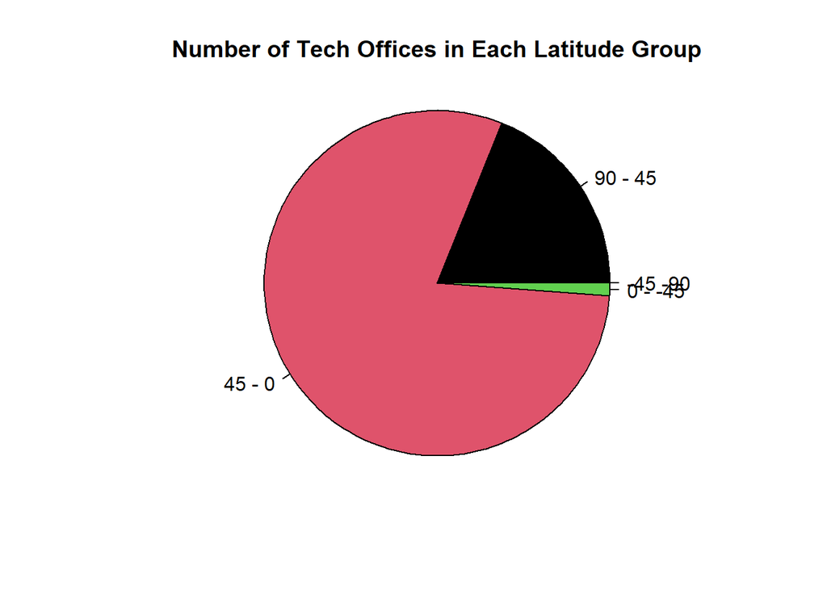

We chose to use a pie chart as it is an easy and quick way to observe how the data is organized by size. Since the pie chart would be too hard to read if it was sorted by all possible countries that have offices, we decided to sort the offices by their latitude data into 4 sections (-90 to -45, -45 to 0, o to 45, and 45 to 90). Our pie char then revealed that a large majority of the offices fall between the latitudes of 0 and 45.

### Chart 3

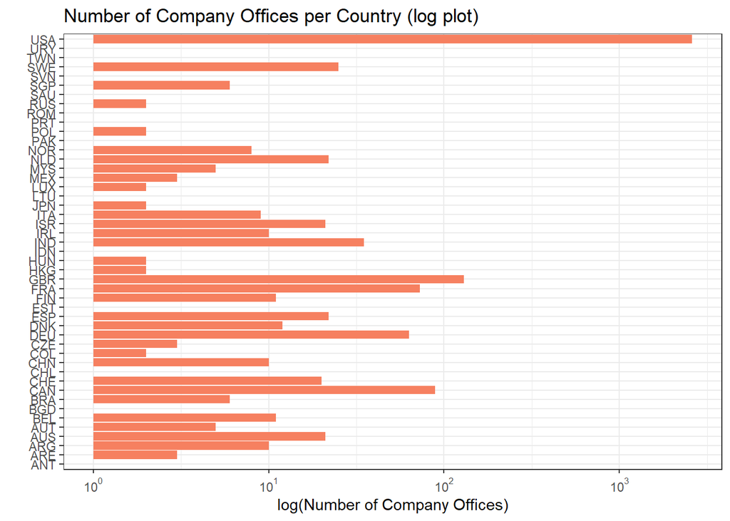

I chose to include a bar chart of the log of the number of company offices in each country because it is still representative of how many more offices there are in some countries without making the visual hard to look at. In the initial variation of this, I graphed the raw number and the US was a very long line where other countries looked closer to 0 on the graph.

## Summary

Our findings show that the most prevalent company name in the data set is Google. Additionally, our team found that most of the companies are coming out of USA, San Francisco, despite the majority of the top gaming company offices being located in USA, New York. While USA, San Francisco may be the origin of many companies, USA, New York appears to be the popularized environment to set up company offices. We also examined the top scoring name of design offices and their associated country and city, which yielded the following results: RentShout, USA, Grover Beach, LEVEL Studios, USA, San Luis Obispo, Mainstream energy, USA, San Luis Obispo. Interestingly, the location USA, San Luis Obispo appears twice on separate accounts, noting that this location may be a well-formed environment for company offices. Lastly, our team analyzed the proportion of the total number of offices from countries outside of the USA to the total number of USA offices, which was (0.4285904). This means that *for every 10 gaming company offices in the USA, there were only about 4 gaming company offices developed in countries outside of the USA*. This showcases a heavily skewed distribution of gaming company offices across different countries, with the majority of offices being developed in the USA.

### Table: Prevalence of Gaming Company Offices Across Different Countries

| Country Code | Number of Offices |
| --- | --- |
| USA | 7520 |
| GBR | 609 |
| CAN | 447 |
| DEU | 280 |
| FRA | 255 |
| IND | 187 |
| AUS | 176 |
| ESP | 141 |
| NLD | 133 |
| SWE | 87 |

This table illustrates the number of gaming company offices across different countries, sorted from highest to lowest, and displaying only the top 10 results through slicing. We included this table to better understand the distribution of offices around the world, and which countries have adopted the largest gaming company office scene.